# Simulations In-Class Project

Due October 13, 2017 at 11:59pm

# Project Goals:

With this project we will simulate a famous probability problem. This will not require knowledge of probability or statistics but only the logic to follow the steps in order to simulate this problem. This is one way to solve problems by using the computer.

1. **Gambler’s Ruin**: Suppose you have a bankroll of $1000 and make bets of $100 on a fair game. By simulating the outcome directly for at most 5000 iterations of the game (or hands), estimate:

```r
game <- function(p, n){
 output <- data.frame(nrow=n,ncol=2)
  colnames(output) = c("times_of_bets","bankroll")
  for(i in 1:n){
    bankroll = 1000
    bet = 100
    n_bet = 0
    while(bankroll>0 & n_bet < 5000){
      bankroll = bankroll +(2*rbinom(1,1,p)-1)*bet
      n_bet = n_bet + 1
    }
  output[i,1] = n_bet
  output[i,2] = bankroll
}
return(output)
}
```

```
a. the probability that you have "busted" (lost all your money) by the time you have placed your one hundredth bet.
```

```r
prob <- function(time_bust){
  x <- game(0.5,5000)[,1]
s = 0
for( i in 1:5000){
  if(x[i] <= time_bust){
    s = s+1
  }
  s
}
p <- s/5000
}
p1 <- prob(100)
p1
```

```
## [1] 0.3302
```

```
b. the probability that you have busted by the time you have placed your five hundredth bet by simulating the outcome directly.
```

```r
p2 <- prob(500)
p2
```

```
## [1] 0.6508
```

```
c. the mean time you go bust, given that you go bust within the first 5000 hands.
```

```r
x1 <- game(0.5, 500)
library(dplyr)
mean_time <- x1 %>%
  filter(x1[,2]==0) %>%
  summarise(mean(times_of_bets))
mean_time
```

```
##   mean(times_of_bets)
## 1            505.6027
```

```
d. the mean and variance of your bankroll after 100 hands (including busts).
```

```r
game1 <- function(bankroll, bet, p, n){
  # n is the number of hands the gambler has played
  n_game <- 0
  while(bankroll > 0 & n_game < n){
    if(rbinom(1,1,p) == 1){
      bankroll = bankroll + bet
    } else {
        bankroll = bankroll - bet
    }
    n_game <- n_game +1
  }
  return(bankroll)
}
mean_bankroll1 <- mean(replicate(5000,game1(1000,100,0.5,100)))
var_bankroll1 <- var(replicate(5000,game1(1000,100,0.5,100)))
```

```
e. the mean and variance of your bankroll after 500 hands (including busts).
```

```r
mean_bankroll2 <- mean(replicate(5000,game1(1000,100,0.5,500)))
var_bankroll2 <- var(replicate(5000,game1(1000,100,0.5,500)))
```

Note: you *must* stop playing if your player has gone bust. How will you handle this in the `for` loop?

2. Repeat the previous problem with betting on black in American roulette, where the probability of winning on any spin is 18/38 for an even payout.
1. the probability that you have “busted” (lost all your money) by the time you have placed your one hundredth bet.

```r
prob1 <- function(time_bust){
  x <- game(18/38,5000)[,1]
s = 0
for( i in 1:5000){
  if(x[i] <= time_bust){
    s = s+1
  }
  s
}
p <- s/5000
}
p3 <- prob1(100)
p3
```

```
## [1] 0.5082
```

```
b. the probability that you have busted by the time you have placed your five hundredth bet by simulating the outcome directly.
```

```r
p4 <- prob1(500)
p4
```

```
## [1] 0.9152
```

```
c. the mean time you go bust, given that you go bust within the first 5000 hands.
```

```r
x2 <- game(18/38, 500)
library(dplyr)
mean_time1 <- x2 %>%
  filter(x2[,2]==0) %>%
  summarise(mean(times_of_bets))
mean_time1
```

```
##   mean(times_of_bets)
## 1             175.952
```

```
d. the mean and variance of your bankroll after 100 hands (including busts).
```

```r
mean_bankroll3 <- mean(replicate(5000,game1(1000,100,18/38,100)))
var_bankroll3 <- var(replicate(5000,game1(1000,100,18/38,100)))
```

```
e. the mean and variance of your bankroll after 500 hands (including busts).
```

```r
mean_bankroll4 <- mean(replicate(5000,game1(1000,100,18/38,500)))
var_bankroll4 <- var(replicate(5000,game1(1000,100,18/38,500)))
```

3. **Markov Chains**. Suppose you have a game where the probability of winning on your first hand is 48%; each time you win, that probability goes up by one percentage point for the next game (to a maximum of 100%, where it must stay), and each time you lose, it goes back down to 48%. Assume you cannot go bust and that the size of your wager is a constant $100.
   1. Is this a fair game? Simulate one hundred thousand sequential hands to determine the size of your return. Then repeat this simulation 99 more times to get a range of values to calculate the expectation.

```r
game2<- function(nn, start, bankroll, bet, increment){
  output <- rep(NA,nn)
  output[1] <- start

      for(i in 2:nn){
        if(rbinom(1,1,output[i-1])==1){
          output[i] <- output[i-1] + increment
          } else {
            output[i] <- start
          }
        bankroll = bankroll + (2* rbinom(1,1,output[i])-1)*bet

        }
  return(c(bankroll,mean(output[i]),i))
}

x3 <- game2(10000,0.48,0,100,0.01)

x4 <- game2(100,0.48,0,100,0.01)[1]
exp_p <- mean(x4)
# the expectation of bankroll is less than 0, so it is not a fair game
```

```
b. Repeat this process but change the starting probability to a new value within 2% either way. Get the expected return after 100 repetitions. Keep exploring until you have a return value that is as fair as you can make it. Can you do this automatically?
```

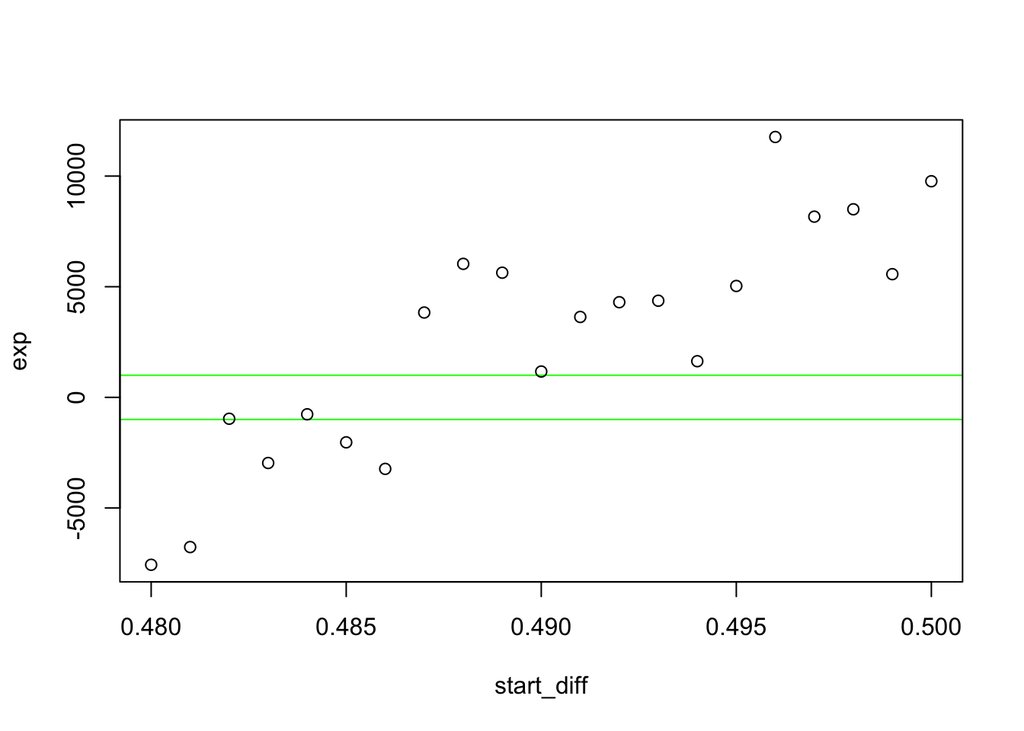

```r
start_diff <- seq(0.48,0.50,by=0.001)
exp <- vector("double",length(start_diff))
for(i in 1:length(start_diff)){
  exp[i] <- mean(game2(10000, start_diff[i], 0, 100, 0.01))
}
plot(y=exp,x=start_diff,abline(h=c(-1000,1000),col="green"))
```